# Script to work with Landsat bands derived from GEE

Read and manipulation data, calculate indices

Alicia Valdés

16 julio 2025

# Load libraries

```r
library(signal)
library(tidyverse)
library(here)
library(lubridate)
library(dtplyr)
library(sf)
library(knitr)
library(mgcv)
library(future)
library(furrr)
library(progressr)
library(pracma)
```

# Set a simple console progress bar

```r
handlers("txtprogressbar") # Simple console progress bar
```

# Load previously created objects

```r
load(file = "objects/GAM_data_Landsat.Rdata")
```

[output not shown]

```r
load(file = "objects/smoothed_data_Landsat.Rdata")
```

[output not shown]

# Define printall function

```r
printall <- function(tibble) {
  print(tibble, width = Inf)
  }
```

# Read files with band data

I got these files using the GEE code prepared by Bea.

```r
# Set the folder path
folder_path <- "C:/Data/MOTIVATE/MOTIVATE_RS_data/Landsat/Bands/all"

# List CSV files
csv_files <- list.files(folder_path, full.names = TRUE, recursive = TRUE)

# Function to extract biogeo and unit from the filename
extract_info <- function(filename) {
  first_word <- strsplit(filename, "_")[[1]][1]
  biogeo <- str_extract(first_word,
                        "^(ALP|ANA|ARC|ATL|BLACKSEA|BOR|CON|MACARONESIA|MED|PANONIA|STEPPIC)")
  unit <- str_remove(first_word, biogeo)
  if (is.na(unit) || unit == "") unit <- NA_character_
  list(biogeo = biogeo, unit = unit)
  }


# Define column types: force RSrvypl to character, others auto-detected
custom_col_types <- cols(
  RSrvypl = col_character(),
  RSrvyst = col_character(),
  default = col_guess()
)

# Read and process each file
data_list <- lapply(csv_files, function(file) {
  info <- extract_info(basename(file)) # Use only the filename

  # Read the file
  df <- read_csv(file, col_types = custom_col_types) %>%
    # Remove columns that give column type problems when combining data
    select(-starts_with("EUNIS"), -starts_with("ReSurvey")) %>%
    mutate(biogeo = info$biogeo, unit = info$unit)

  return(df)
  })
beep
```

[output not shown]

```r
beep()

# Combine all data
data_RS_Landsat_bands <- bind_rows(data_list) %>%
  rename(PlotObservationID = PltObID)

# View the resulting tibble
print(data_RS_Landsat_bands)
```

| system:index | Blue | Green | Lctnmth | NIR | PLOT | PlotObservationID | RS_CODE | RSrvypl | RSrvyst | Red | SWIR1 | UNIT | date | image_id | obs_nq_ | time_utc | timestamp | year | .geo | biogeo | unit | X1 | X2 | X3 |
| --- | --- | --- | --- | --- | --- | --- | --- | --- | --- | --- | --- | --- | --- | --- | --- | --- | --- | --- | --- | --- | --- | --- | --- | --- |
| 37_1_1_1_LT05_194028_19840902_00000000000000020bd8_0 | 9439 | 10719 | Location from a description | 16468 | 98448 | 338955 | IT_0012a | R2522 | Aosta | 10783 | 15685 | ALPALPS_0 | 1984-09-02 | 1_1_1_LT05_194028_19840902 | 330725 | 09:40:00 | 462966047337 | 1984 | {"geodesic":false,"type":"Point","coordinates":[7.471769075575076,45.74336613547544]} | ALP | ALPS | NA | NA | NA |
| 37_1_1_1_LT05_195028_19840418_00000000000000020bd8_0 | 11076 | 12092 | Location from a description | 15378 | 98448 | 338955 | IT_0012a | R2522 | Aosta | 12612 | 16575 | ALPALPS_0 | 1984-04-18 | 1_1_1_LT05_195028_19840418 | 330725 | 09:44:00 | 451129444826 | 1984 | {"geodesic":false,"type":"Point","coordinates":[7.471769075575076,45.74336613547544]} | ALP | ALPS | NA | NA | NA |
| 37_1_1_1_LT05_195028_19840621_00000000000000020bd8_0 | 11557 | 12406 | Location from a description | 18908 | 98448 | 338955 | IT_0012a | R2522 | Aosta | 12022 | 15201 | ALPALPS_0 | 1984-06-21 | 1_1_1_LT05_195028_19840621 | 330725 | 09:45:00 | 456659117952 | 1984 | {"geodesic":false,"type":"Point","coordinates":[7.471769075575076,45.74336613547544]} | ALP | ALPS | NA | NA | NA |
| 37_1_1_1_LT05_195028_19840909_00000000000000020bd8_0 | 9724 | 10983 | Location from a description | 16324 | 98448 | 338955 | IT_0012a | R2522 | Aosta | 11161 | 15317 | ALPALPS_0 | 1984-09-09 | 1_1_1_LT05_195028_19840909 | 330725 | 09:46:00 | 463571219832 | 1984 | {"geodesic":false,"type":"Point","coordinates":[7.471769075575076,45.74336613547544]} | ALP | ALPS | NA | NA | NA |
| 37_1_1_1_LT05_195028_19841128_00000000000000020bd8_0 | 10381 | 10958 | Location from a description | 14713 | 98448 | 338955 | IT_0012a | R2522 | Aosta | 11370 | 17893 | ALPALPS_0 | 1984-11-28 | 1_1_1_LT05_195028_19841128 | 330725 | 09:46:00 | 470483208320 | 1984 | {"geodesic":false,"type":"Point","coordinates":[7.471769075575076,45.74336613547544]} | ALP | ALPS | NA | NA | NA |
| 38_1_1_1_LT05_194028_19850804_000000000000000201d4_0 | 9391 | 10385 | Location from accurate map | 15587 | 96987 | 335493 | CH_0001i | 1308 | Z4754 | 10449 | 14700 | ALPALPS_0 | 1985-08-04 | 1_1_1_LT05_194028_19850804 | 327263 | 09:40:00 | 491996429531 | 1985 | {"geodesic":false,"type":"Point","coordinates":[7.699257388077778,45.994060025921684]} | ALP | ALPS | NA | NA | NA |
| 38_1_1_1_LT05_194028_19850804_000000000000000201d6_0 | 10915 | 12011 | Location from accurate map | 15740 | 96988 | 335495 | CH_0001i | 1309 | Z4755 | 12007 | 16496 | ALPALPS_0 | 1985-08-04 | 1_1_1_LT05_194028_19850804 | 327265 | 09:40:00 | 491996429531 | 1985 | {"geodesic":false,"type":"Point","coordinates":[7.699289012985594,45.992710321100404]} | ALP | ALPS | NA | NA | NA |
| 38_1_1_1_LT05_194028_19850921_000000000000000201d4_0 | 8693 | 9269 | Location from accurate map | 11538 | 96987 | 335493 | CH_0001i | 1308 | Z4754 | 9476 | 11786 | ALPALPS_0 | 1985-09-21 | 1_1_1_LT05_194028_19850921 | 327263 | 09:39:00 | 496143595700 | 1985 | {"geodesic":false,"type":"Point","coordinates":[7.699257388077778,45.994060025921684]} | ALP | ALPS | NA | NA | NA |
| 38_1_1_1_LT05_194028_19850921_000000000000000201d6_0 | 9438 | 10152 | Location from accurate map | 12087 | 96988 | 335495 | CH_0001i | 1309 | Z4755 | 10252 | 12880 | ALPALPS_0 | 1985-09-21 | 1_1_1_LT05_194028_19850921 | 327265 | 09:39:00 | 496143595700 | 1985 | {"geodesic":false,"type":"Point","coordinates":[7.699289012985594,45.992710321100404]} | ALP | ALPS | NA | NA | NA |
| 38_1_1_1_LT05_195028_19850131_00000000000000020bd9_0 | 12633 | 11665 | Location from a description | 10640 | 98449 | 338956 | IT_0012a | R2523 | Aosta | 11340 | 7809 | ALPALPS_0 | 1985-01-31 | 1_1_1_LT05_195028_19850131 | 330726 | 09:47:00 | 476012838760 | 1985 | {"geodesic":false,"type":"Point","coordinates":[7.23556011203433,45.70026765969665]} | ALP | ALPS | NA | NA | NA |

[output cut: 990 more lines]

```r
# Counts per biogeo and unit
print(data_RS_Landsat_bands %>% count(biogeo, unit), n = 100)
```

| biogeo | unit | n |
| --- | --- | --- |
| ALP | ALPS | 116038 |
| ALP | ATRA | 13871 |
| ALP | BALKAN | 1957 |
| ALP | ENNINE | 865 |
| ALP | NORDIC | 1153 |
| ALP | PYR | 9348 |
| ALP | ROMANIAN | 496 |
| ARC | NORWAY | 124 |
| ATL | BENELUX | 402573 |
| ATL | BRITAIN | 208543 |

[output cut: 21 more lines]

# Some checks

Check that the year in the date of the images is not different to the sampling year:

```r
data_RS_Landsat_bands %>% dplyr::filter(year != year(date))
```

| system:index | Blue | Green | Lctnmth | NIR | PLOT | PlotObservationID | RS_CODE | RSrvypl | RSrvyst | Red | SWIR1 | UNIT | date | image_id | obs_nq_ | time_utc | timestamp | year | .geo | biogeo | unit | X1 | X2 | X3 |
| --- | --- | --- | --- | --- | --- | --- | --- | --- | --- | --- | --- | --- | --- | --- | --- | --- | --- | --- | --- | --- | --- | --- | --- | --- |

Check how many different images are for each observation, date and time:

```r
data_RS_Landsat_bands %>% group_by(PlotObservationID, date, time_utc) %>%
  summarise(n_images = n_distinct(image_id), .groups = "drop") %>%
  count(n_images)
```

| n_images | n |
| --- | --- |
| 1 | 2219351 |
| 2 | 176721 |

# Average the bands

When there is more than one image for each point and day, average the values of the bands:

```r
# Summarize the band values conditionally
band_summary <- data_RS_Landsat_bands %>%
  group_by(PlotObservationID, date) %>%
  summarise(
    n_images = n_distinct(image_id),
    Blue = if (n_images > 1) mean(Blue, na.rm = TRUE) else first(Blue),
    Green  = if (n_images > 1) mean(Green,  na.rm = TRUE) else first(Green),
    NIR  = if (n_images > 1) mean(NIR,  na.rm = TRUE) else first(NIR),
    Red  = if (n_images > 1) mean(Red,  na.rm = TRUE) else first(Red),
    SWIR1 = if (n_images > 1) mean(SWIR1,  na.rm = TRUE) else first(SWIR1),
    .groups = "drop"
  )
beep()

# Calculate how many different days for each PlotObservationID
n_days <- band_summary %>%
  group_by(PlotObservationID) %>%
  summarise(n_days = n_distinct(date))

# Join back to original data
data_RS_Landsat_bands_updated <- data_RS_Landsat_bands %>%
  # Remove old band values
  select(-Blue, -Green, -NIR, -Red, -SWIR1) %>%
  # Join band_summary
  left_join(band_summary, by = c("PlotObservationID", "date")) %>%
  # Keep one row per group
  distinct(PlotObservationID, date, .keep_all = TRUE) %>%
  # Remove unwanted columns
  select(-`system:index`, -image_id, -.geo, -time_utc, -timestamp,
         X1, X2, X3) %>%
  # Join
  left_join(n_days)
```

# Calculate indices

```r
# Calculate indices
data_RS_Landsat_bands_indices <- data_RS_Landsat_bands_updated %>%
  # Set PlotObservationID as factor
  mutate(PlotObservationID = factor(PlotObservationID)) %>%
  # Rename the bands
  rename(blue = Blue, green = Green, red = Red, NIR = NIR, SWIR = SWIR1) %>%
  # Scale the bands
  mutate(blue = blue / 10000, green = green / 10000, red = red / 10000,
         NIR = NIR / 10000, SWIR = SWIR / 10000) %>%
  # Create column that combines the day of the month and the time
  mutate(
    date = as.POSIXct(date),
    # Normalize the dates to a fixed year (2000)
    # so that seasonal patterns across different years can be compared visually
    day_month = as.POSIXct(format(date, "2000-%m-%d"))) %>%
  # Create column with DOY
  mutate(DOY = yday(date)) %>%
  # Calculate NDVI
  mutate(NDVI = (NIR - red) / (NIR + red),
         EVI = (NIR - red) * 2.5 / (NIR + 6 * red - 7.5 * blue + 1),
         SAVI = (NIR - red) * 1.5 / (NIR + red + 0.5),
         NDMI = (NIR - SWIR) / (NIR + SWIR),
         NDWI = (green - NIR) / (green + NIR)) #%>%
beep()
  # Setting values of indices outside expected ranges (errors) to NA
  #mutate(EVI = if_else(EVI > 1 | EVI < -1, NA, EVI)) # 1220710 values of EVI as NA
```

Plot n_daytime:

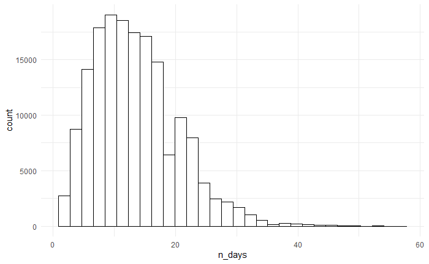

```r
data_RS_Landsat_bands_indices %>%
  group_by(PlotObservationID) %>%
  summarise(n_days = first(n_days)) %>% ungroup() %>%
  ggplot(aes(x = n_days)) + geom_histogram(color = "black", fill = "white") +
  theme_minimal()
```

Much fewer days than with S2!

# HERE: Compute phenological metrics from models fitted to time series data

Using GAMs, reweighting and 3 iterations.

Approach similar to https://doi.org/10.1016/j.jag.2020.102172.

Define function to compute phenology metrics using GAM fit and NDVI / EVI / SAVI:

```r
compute_metrics_models <- function(
  # Data frame df with index values over time (DOY)
  df,
  # Name of the vegetation indices columns (e.g., "NDVI", "EVI", "SAVI")
  index_cols = c("NDVI", "EVI", "SAVI"),
  # Number of iterations for the reweighting process to refine the GAM fit
  max_iter = 3
) {
  # Initialize lists to store results
  metrics_list <- list()
  fits_list <- list()

  # Loop over each index column
  for (index_col in index_cols) {
    # Remove rows with missing index values and sort data by DOY
    df_index <- df %>%
      dplyr::filter(!is.na(.data[[index_col]])) %>%
      arrange(DOY)

    # Replace values in DOY 1–50 and DOY 315–end with separate base values
    base_value_early <- mean(df_index %>%
                               dplyr::filter(DOY >= 1 & DOY <= 50) %>%
                               pull(index_col), na.rm = TRUE)
    base_value_late  <- mean(df_index %>%
                               dplyr::filter(DOY >= 315) %>%
                               pull(index_col), na.rm = TRUE)

    df_index <- df_index %>%
      mutate(!!index_col := case_when(
        DOY <= 50 ~ base_value_early,
        DOY >= 315 ~ base_value_late,
        TRUE ~ .data[[index_col]]
      ))

    # Extract x (DOY) and y (index) vectors for modelling
    x <- df_index$DOY
    y <- df_index[[index_col]]

    # If there are fewer than 11 observations or all values are NA, skip
    # VERIFY if this value is OK!
    if (length(x) < 11 || all(is.na(y))) {
      next
    }

    # Create tibble to store original and predicted index values
    fits_df <- tibble(DOY = x, observed = y)

    # Fit initial GAM (unweighted):
    # Fit a GAM with a thin plate spline (bs = "tp") to smooth the index curve
    gam_unweighted <- mgcv::bam(y ~ s(x, bs = "tp"))
    # Store the predicted values in the unweighted column
    fits_df$unweighted <- predict(gam_unweighted, newdata = tibble(x = x))

    # Iterative reweighted GAM fitting
    weights <- rep(1, length(y)) # Start with equal weights
    for (i in 1:max_iter) {
      # Update prediction and recalculate weights to emphasize
      # points where observed index is higher than predicted
      gam_fit <- mgcv::bam(y ~ s(x, bs = "tp"), weights = weights)
      pred <- predict(gam_fit, newdata = tibble(x = x))
      if (any(is.na(pred))) {
        print(paste("Warning: NA predictions in iteration", i, "for", index_col))
      }
      fits_df[[paste0("iter_", i)]] <- pred

      # Apply weighting only between DOY 50 and 315
      weights <- rep(1, length(y))
      idx_between <- which(x > 50 & x < 315 & !is.na(pred) & pred != 0)
      weights[idx_between] <- (y[idx_between] / pred[idx_between])^4
      weights[weights > 1] <- 1
      weights[is.na(weights)] <- 1
    }

    # Compute phenological metrics for each fit_type
    fit_types <- c("unweighted", paste0("iter_", 1:max_iter))
    for (fit_type in fit_types) {
      pred <- fits_df[[fit_type]]

      if (all(is.na(pred))) {
        print(paste("All predictions are NA for", fit_type, "on", index_col))
      }

      slope <- c(NA, diff(pred))

      pos <- {
        idx <- which(x >= 50 & x <= 315)
        if (length(idx) > 0) x[idx][which.max(pred[idx])] else NA_real_
      }

      if (is.na(pos)) {
        print(paste("POS is NA for", fit_type, "on", index_col))
      }

      sos <- {
        idx <- which(x < pos)
        if (length(idx) > 0) {
          sub_x <- x[idx]
          sub_slope <- slope[idx]
          sub_x[which.max(sub_slope)]
        } else NA_real_
      }

      eos <- {
        idx <- which(x > pos)
        if (length(idx) > 0) {
          sub_x <- x[idx]
          sub_slope <- slope[idx]
          sub_x[which.min(sub_slope)]
        } else NA_real_
      }

      # Compute time-integrated index (AUC) between SOS and EOS
      integration_idx <- which(x >= sos & x <= eos & !is.na(pred))
      if (length(integration_idx) > 1) {
        auc <- sum(diff(x[integration_idx]) *
                     zoo::rollmean(pred[integration_idx], 2))
      } else {
        auc <- NA_real_
      }

      metrics_list[[paste(index_col, fit_type, sep = "_")]] <- tibble(
        PlotObservationID = unique(df$PlotObservationID),
        index = index_col,
        fit_type = fit_type,
        sos = sos,
        pos = pos,
        eos = eos,
        auc = auc
      )
    }

    # Store fits in long format
    fits_long <- fits_df %>%
      pivot_longer(cols = -DOY, names_to = "fit_type", values_to = "value") %>%
      mutate(
        PlotObservationID = unique(df$PlotObservationID),
        index = index_col
      )

    fits_list[[index_col]] <- fits_long
  }

  # Fallback in case no metrics were computed
  if (length(metrics_list) == 0) {
    print(paste("No metrics computed for PlotObservationID:",
                unique(df$PlotObservationID)))
    return(tibble())
  }

  # Combine metrics and fits into a single GAM_data tibble
  metrics_df <- bind_rows(metrics_list[!sapply(metrics_list, is.null)])
  fits_df <- bind_rows(fits_list)

  GAM_data <- fits_df %>%
    left_join(metrics_df, by = c("PlotObservationID", "index", "fit_type")) %>%
    mutate(method = "GAM") %>%
    # Specify column order
    select(PlotObservationID, DOY, method, fit_type, index, value,
           sos, pos, eos, auc)

  # Return the combined tibble
  return(GAM_data)
}
```

Look:

```r
GAM_data
```

Save as an object:

## Boxplot comparing moments for different indices

```r
GAM_data %>% dplyr::filter(fit_type =="iter_3") %>%
  select(PlotObservationID, index, sos, pos, eos) %>% distinct() %>%
  pivot_longer(cols = c(sos, pos, eos),
               names_to = "moment", values_to = "value") %>%
  ggplot(aes(x = moment, y = value, fill = index)) + geom_boxplot()
```

## Plot fit and moments for each PlotObservationID

Save each plot to a file:

# Smooth the time series of NDMI and NDWI

Using GAM, without replacing values in DOY 1–50 and DOY 315–end with separate base values, later use only unweighted GAM

```r
compute_unweighted_fit <- function(
    # Data frame df with index values over time (DOY)
    df,
    # Name of the vegetation indices columns (e.g., "NDVI", "EVI", "SAVI)
    index_cols = c("NDMI", "NDWI")
) {
  # Initialize list to store results
  fits_list <- list()

  # Loop over each index column
  for (index_col in index_cols) {
    df_index <- df %>%
      # Remove rows with missing index values and sort data by DOY
      filter(!is.na(.data[[index_col]])) %>% arrange(DOY)

    # Extract x (DOY) and y (index) vectors for modelling
    x <- df_index$DOY
    y <- df_index[[index_col]]

    # If there are fewer than 11 observations or all values are NA, skip
    if (length(x) < 11 || all(is.na(y))) {
      next
    }

    # Fit GAM (unweighted) with a thin plate spline (bs = "tp")
    # to smooth the index curve
    gam_unweighted <- mgcv::bam(y ~ s(x, bs = "tp"))
    pred <- predict(gam_unweighted, newdata = tibble(x = x))

    # Create tibble to store original and predicted index values
    fits_df <- tibble(
      PlotObservationID = unique(df$PlotObservationID),
      DOY = x,
      index = index_col,
      value = pred
    )

    fits_list[[index_col]] <- fits_df
  }

  if (length(fits_list) == 0) {
    return(tibble())
  }

  bind_rows(fits_list)
}
```

Look:

```r
smoothed_data
```

Save as an object:

## Plot fit and moments for each PlotObservationID

Save each plot to a file:

# Get indices data (max. and min.)

Careful! These maximum and minimum values are from the smoothed time series. For NDVI / EVI / SAVI values in DOY 1–50 and DOY 315–end, remember that the GAM smoothing function replaced the original values with the mean base value of observations during each of these respective periods. This was so far not done for NDMI and NDWI.

```r
final_indices_data <- GAM_data %>%
  # Filter for iter_3
  dplyr::filter(fit_type =="iter_3") %>%
  select(-method, -fit_type) %>%
  group_by(PlotObservationID, index) %>%
  summarise(max = max(value), min = min(value)) %>%
  ungroup() %>%
  pivot_wider(names_from = index, values_from = c(max, min),
              names_glue = "{index}_{.value}") %>%
  full_join(
    smoothed_data %>%
      group_by(PlotObservationID, index) %>%
      summarise(max = max(value), min = min(value)) %>%
      ungroup() %>%
      pivot_wider(names_from = index, values_from = c(max, min),
                  names_glue = "{index}_{.value}")
    )
```

# Get phenology data

Use GAM iter_3 to get dates of the moments, values at those moments and AUC (time-integrated indices) between SOS and EOS:

```r
# Join to get values at SOS, POS, EOS and auc
final_phenology_data <- GAM_data %>%
  # Filter for iter_3
  dplyr::filter(fit_type =="iter_3") %>%
  select(-method, -fit_type) %>%
  mutate(
    stage = case_when(
      DOY == sos ~ "sos",
      DOY == pos ~ "pos",
      DOY == eos ~ "eos",
      TRUE ~ NA_character_
    )
  ) %>%
  dplyr::filter(!is.na(stage)) %>%
  select(PlotObservationID, index, stage, doy = DOY, value) %>%
  pivot_wider(
    names_from = c(index, stage),
    values_from = c(doy, value),
    names_glue = "{index}_{stage}_{.value}"
  ) %>%
  # Convert list cols to regular numeric cols
  mutate(
    NDVI_sos_value = map_dbl(NDVI_sos_value, 1),
    NDVI_pos_value = map_dbl(NDVI_pos_value, 1),
    NDVI_eos_value = map_dbl(NDVI_eos_value, 1),
    EVI_sos_value = map_dbl(EVI_sos_value, 1),
    EVI_pos_value = map_dbl(EVI_pos_value, 1),
    EVI_eos_value = map_dbl(EVI_eos_value, 1),
    SAVI_sos_value = map_dbl(SAVI_sos_value, 1),
    SAVI_pos_value = map_dbl(SAVI_pos_value, 1),
    SAVI_eos_value = map_dbl(SAVI_eos_value, 1)
  ) %>%
  full_join(GAM_data %>% dplyr::filter(fit_type == "iter_3") %>%
              distinct(PlotObservationID, index, auc) %>%
              pivot_wider(names_from = index, values_from = auc,
                          names_glue = "{index}_{.value}"))
```

# Join indices and phenology data

```r
final_RS_data <- full_join(final_indices_data, final_phenology_data)
```

# Add EUNIS codes

```r
db_Europa_allobs <- read_csv(
  here("data", "clean", "db_Europa_allobs.csv")) %>%
  select(PlotObservationID, EUNISa_1, EUNISa_1_descr,
         EUNISa_2, EUNISa_2_descr) %>%
  mutate(PlotObservationID = factor(PlotObservationID),
         EUNISa_1 = factor(EUNISa_1), EUNISa_2 = factor(EUNISa_2))
```

```r
final_RS_data <- final_RS_data %>% left_join(db_Europa_allobs)
```

```r
data_RS_Landsat_bands_indices <- data_RS_Landsat_bands_indices %>%
  left_join(db_Europa_allobs)
```

# Monthly spectrophenology per habitat type

```r
# Prepare the data
data_monthly_EUNISa_1 <- data_RS_Landsat_bands_indices %>%
  mutate(month = month(date, label = TRUE, abbr = TRUE)) %>%
  group_by(month, EUNISa_1, EUNISa_1_descr) %>%
  summarise(
    mean_NDVI = mean(NDVI, na.rm = TRUE),
    sd_NDVI = sd(NDVI, na.rm = TRUE),
    mean_EVI = mean(EVI, na.rm = TRUE),
    sd_EVI = sd(EVI, na.rm = TRUE),
    mean_SAVI = mean(SAVI, na.rm = TRUE),
    sd_SAVI = sd(SAVI, na.rm = TRUE),
    .groups = "drop"
  )
data_monthly_EUNISa_2 <- data_RS_Landsat_bands_indices %>%
  mutate(month = month(date, label = TRUE, abbr = TRUE)) %>%
  group_by(month, EUNISa_1, EUNISa_1_descr, EUNISa_2, EUNISa_2_descr) %>%
  summarise(
    mean_NDVI = mean(NDVI, na.rm = TRUE),
    sd_NDVI = sd(NDVI, na.rm = TRUE),
    mean_EVI = mean(EVI, na.rm = TRUE),
    sd_EVI = sd(EVI, na.rm = TRUE),
    mean_SAVI = mean(SAVI, na.rm = TRUE),
    sd_SAVI = sd(SAVI, na.rm = TRUE),
    .groups = "drop"
  )
```

```r
# Plots

# EUNISa_1
ggplot(data_monthly_EUNISa_1,
       aes(x = month, y = mean_NDVI, color = EUNISa_1, group = EUNISa_1)) +
  geom_point(size = 3) +
  geom_line() +
  geom_errorbar(aes(ymin = mean_NDVI - sd_NDVI, ymax = mean_NDVI + sd_NDVI),
                width = 0.2) +
  labs(
    title = "Monthly NDVI by Habitat Type",
    x = "Month",
    y = "NDVI",
    color = "Habitat (EUNISa_1)"
  ) +
  theme_minimal()

ggplot(data_monthly_EUNISa_1,
       aes(x = month, y = mean_EVI, color = EUNISa_1, group = EUNISa_1)) +
  geom_point(size = 3) +
  geom_line() +
  geom_errorbar(aes(ymin = mean_EVI - sd_EVI, ymax = mean_EVI + sd_EVI),
                width = 0.2) +
  labs(
    title = "Monthly EVI by Habitat Type",
    x = "Month",
    y = "EVI",
    color = "Habitat (EUNISa_1)"
  ) +
  theme_minimal()

ggplot(data_monthly_EUNISa_1,
       aes(x = month, y = mean_SAVI, color = EUNISa_1, group = EUNISa_1)) +
  geom_point(size = 3) +
  geom_line() +
  geom_errorbar(aes(ymin = mean_SAVI - sd_SAVI, ymax = mean_SAVI + sd_SAVI),
                width = 0.2) +
  labs(
    title = "Monthly SAVI by Habitat Type",
    x = "Month",
    y = "SAVI",
    color = "Habitat (EUNISa_1)"
  ) +
  theme_minimal()

# EUNISa_2

# NDVI
ggplot(data_monthly_EUNISa_2 %>% filter(EUNISa_1 == "Q" & !is.na(EUNISa_2)),
       aes(x = month, y = mean_NDVI, color = EUNISa_2_descr,
           group = EUNISa_2_descr)) +
  geom_point(size = 3) +
  geom_line() +
  geom_errorbar(aes(ymin = mean_NDVI - sd_NDVI, ymax = mean_NDVI + sd_NDVI),
                width = 0.2) +
  labs(
    title = "Monthly NDVI by Habitat Type",
    x = "Month",
    y = "NDVI",
    color = "Habitat (EUNISa_2)"
  ) +
  theme_minimal()

ggplot(data_monthly_EUNISa_2 %>% filter(EUNISa_1 == "R" & !is.na(EUNISa_2)),
       aes(x = month, y = mean_NDVI, color = EUNISa_2_descr,
           group = EUNISa_2_descr)) +
  geom_point(size = 3) +
  geom_line() +
  geom_errorbar(aes(ymin = mean_NDVI - sd_NDVI, ymax = mean_NDVI + sd_NDVI),
                width = 0.2) +
  labs(
    title = "Monthly NDVI by Habitat Type",
    x = "Month",
    y = "NDVI",
    color = "Habitat (EUNISa_2)"
  ) +
  theme_minimal()

ggplot(data_monthly_EUNISa_2 %>% filter(EUNISa_1 == "S" & !is.na(EUNISa_2)),
       aes(x = month, y = mean_NDVI, color = EUNISa_2_descr,
           group = EUNISa_2_descr)) +
  geom_point(size = 3) +
  geom_line() +
  geom_errorbar(aes(ymin = mean_NDVI - sd_NDVI, ymax = mean_NDVI + sd_NDVI),
                width = 0.2) +
  labs(
    title = "Monthly NDVI by Habitat Type",
    x = "Month",
    y = "NDVI",
    color = "Habitat (EUNISa_2)"
  ) +
  theme_minimal()

ggplot(data_monthly_EUNISa_2 %>% filter(EUNISa_1 == "T" & !is.na(EUNISa_2)),
       aes(x = month, y = mean_NDVI, color = EUNISa_2_descr,
           group = EUNISa_2_descr)) +
  geom_point(size = 3) +
  geom_line() +
  geom_errorbar(aes(ymin = mean_NDVI - sd_NDVI, ymax = mean_NDVI + sd_NDVI),
                width = 0.2) +
  labs(
    title = "Monthly NDVI by Habitat Type",
    x = "Month",
    y = "NDVI",
    color = "Habitat (EUNISa_2)"
  ) +
  theme_minimal()

# EVI
ggplot(data_monthly_EUNISa_2 %>% filter(EUNISa_1 == "Q" & !is.na(EUNISa_2)),
       aes(x = month, y = mean_EVI, color = EUNISa_2_descr,
           group = EUNISa_2_descr)) +
  geom_point(size = 3) +
  geom_line() +
  geom_errorbar(aes(ymin = mean_EVI - sd_EVI, ymax = mean_EVI + sd_EVI),
                width = 0.2) +
  labs(
    title = "Monthly EVI by Habitat Type",
    x = "Month",
    y = "EVI",
    color = "Habitat (EUNISa_2)"
  ) +
  theme_minimal()

ggplot(data_monthly_EUNISa_2 %>% filter(EUNISa_1 == "R" & !is.na(EUNISa_2)),
       aes(x = month, y = mean_EVI, color = EUNISa_2_descr,
           group = EUNISa_2_descr)) +
  geom_point(size = 3) +
  geom_line() +
  geom_errorbar(aes(ymin = mean_EVI - sd_EVI, ymax = mean_EVI + sd_EVI),
                width = 0.2) +
  labs(
    title = "Monthly EVI by Habitat Type",
    x = "Month",
    y = "EVI",
    color = "Habitat (EUNISa_2)"
  ) +
  theme_minimal()

ggplot(data_monthly_EUNISa_2 %>% filter(EUNISa_1 == "S" & !is.na(EUNISa_2)),
       aes(x = month, y = mean_EVI, color = EUNISa_2_descr,
           group = EUNISa_2_descr)) +
  geom_point(size = 3) +
  geom_line() +
  geom_errorbar(aes(ymin = mean_EVI - sd_EVI, ymax = mean_EVI + sd_EVI),
                width = 0.2) +
  labs(
    title = "Monthly EVI by Habitat Type",
    x = "Month",
    y = "EVI",
    color = "Habitat (EUNISa_2)"
  ) +
  theme_minimal()

ggplot(data_monthly_EUNISa_2 %>% filter(EUNISa_1 == "T" & !is.na(EUNISa_2)),
       aes(x = month, y = mean_EVI, color = EUNISa_2_descr,
           group = EUNISa_2_descr)) +
  geom_point(size = 3) +
  geom_line() +
  geom_errorbar(aes(ymin = mean_EVI - sd_EVI, ymax = mean_EVI + sd_EVI),
                width = 0.2) +
  labs(
    title = "Monthly EVI by Habitat Type",
    x = "Month",
    y = "EVI",
    color = "Habitat (EUNISa_2)"
  ) +
  theme_minimal()

# SAVI
ggplot(data_monthly_EUNISa_2 %>% filter(EUNISa_1 == "Q" & !is.na(EUNISa_2)),
       aes(x = month, y = mean_SAVI, color = EUNISa_2_descr,
           group = EUNISa_2_descr)) +
  geom_point(size = 3) +
  geom_line() +
  geom_errorbar(aes(ymin = mean_SAVI - sd_SAVI, ymax = mean_SAVI + sd_SAVI),
                width = 0.2) +
  labs(
    title = "Monthly SAVI by Habitat Type",
    x = "Month",
    y = "SAVI",
    color = "Habitat (EUNISa_2)"
  ) +
  theme_minimal()

ggplot(data_monthly_EUNISa_2 %>% filter(EUNISa_1 == "R" & !is.na(EUNISa_2)),
       aes(x = month, y = mean_SAVI, color = EUNISa_2_descr,
           group = EUNISa_2_descr)) +
  geom_point(size = 3) +
  geom_line() +
  geom_errorbar(aes(ymin = mean_SAVI - sd_SAVI, ymax = mean_SAVI + sd_SAVI),
                width = 0.2) +
  labs(
    title = "Monthly SAVI by Habitat Type",
    x = "Month",
    y = "SAVI",
    color = "Habitat (EUNISa_2)"
  ) +
  theme_minimal()

ggplot(data_monthly_EUNISa_2 %>% filter(EUNISa_1 == "S" & !is.na(EUNISa_2)),
       aes(x = month, y = mean_SAVI, color = EUNISa_2_descr,
           group = EUNISa_2_descr)) +
  geom_point(size = 3) +
  geom_line() +
  geom_errorbar(aes(ymin = mean_SAVI - sd_SAVI, ymax = mean_SAVI + sd_SAVI),
                width = 0.2) +
  labs(
    title = "Monthly SAVI by Habitat Type",
    x = "Month",
    y = "SAVI",
    color = "Habitat (EUNISa_2)"
  ) +
  theme_minimal()

ggplot(data_monthly_EUNISa_2 %>% filter(EUNISa_1 == "T" & !is.na(EUNISa_2)),
       aes(x = month, y = mean_SAVI, color = EUNISa_2_descr,
           group = EUNISa_2_descr)) +
  geom_point(size = 3) +
  geom_line() +
  geom_errorbar(aes(ymin = mean_SAVI - sd_SAVI, ymax = mean_SAVI + sd_SAVI),
                width = 0.2) +
  labs(
    title = "Monthly SAVI by Habitat Type",
    x = "Month",
    y = "SAVI",
    color = "Habitat (EUNISa_2)"
  ) +
  theme_minimal()
```

# Calculate other phenological metrics

```r
final_RS_data <- final_RS_data %>%
  mutate(
    # Growing season duration
    NDVI_gsd = NDVI_eos_doy - NDVI_sos_doy,
    EVI_gsd = NDVI_eos_doy - NDVI_sos_doy,
    SAVI_gsd = SAVI_eos_doy - SAVI_sos_doy,
    # Difference in value between pos and sos
    NDVI_diff_pos_sos_value = NDVI_pos_value - NDVI_sos_value,
    EVI_diff_pos_sos_value = EVI_pos_value - EVI_sos_value,
    SAVI_diff_pos_sos_value = SAVI_pos_value - SAVI_sos_value,
    # Difference in value between pos and eos
    NDVI_diff_pos_eos_value = NDVI_pos_value - NDVI_eos_value,
    EVI_diff_pos_eos_value = EVI_pos_value - EVI_eos_value,
    SAVI_diff_pos_eos_value = SAVI_pos_value - SAVI_eos_value,
    # Difference in doy between pos and sos
    NDVI_diff_pos_sos_doy = NDVI_pos_doy - NDVI_sos_doy,
    EVI_diff_pos_sos_doy = EVI_pos_doy - EVI_sos_doy,
    SAVI_diff_pos_sos_doy = SAVI_pos_doy - SAVI_sos_doy,
    # Difference in doy between eos and pos
    NDVI_diff_eos_pos_doy = NDVI_eos_doy - NDVI_pos_doy,
    EVI_diff_eos_pos_doy = EVI_eos_doy - EVI_pos_doy,
    SAVI_diff_eos_pos_doy = SAVI_eos_doy - SAVI_pos_doy
  )
```

## Checks

```r
# Growing season duration should be positive
nrow(final_RS_data %>%
       dplyr::filter(NDVI_gsd <= 0 | EVI_gsd <= 0 | SAVI_gsd <= 0))
# Difference in value between pos and sos should be positive
nrow(final_RS_data %>%
       dplyr::filter(NDVI_diff_pos_sos_value <= 0))
nrow(final_RS_data %>%
       dplyr::filter(EVI_diff_pos_sos_value <= 0))
nrow(final_RS_data %>%
       dplyr::filter(SAVI_diff_pos_sos_value <= 0))
# Difference in value between pos and eos should be positive
nrow(final_RS_data %>%
       dplyr::filter(NDVI_diff_pos_eos_value <= 0))
nrow(final_RS_data %>%
       dplyr::filter(EVI_diff_pos_eos_value <= 0))
nrow(final_RS_data %>%
       dplyr::filter(SAVI_diff_pos_eos_value <= 0))
# Difference in doy between pos and sos should be positive
nrow(final_RS_data %>%
       dplyr::filter(NDVI_diff_pos_sos_doy <= 0 | EVI_diff_pos_sos_doy <= 0 |
                       SAVI_diff_pos_sos_doy <= 0))
# Difference in doy between eos and pos should be positive
nrow(final_RS_data %>%
       dplyr::filter(NDVI_diff_eos_pos_doy <= 0 | EVI_diff_eos_pos_doy <= 0 |
                       SAVI_diff_eos_pos_doy <= 0))
```

# HERE: Run. Detect number of peaks in smoothed curves

```r
# Set up parallel plan
plan(multisession, workers = min(parallel::detectCores() - 1))

# Define peak-counting function
count_peaks <- function(df) {
  # Convert 1D array column to numeric vector
  y <- as.numeric(df$value)

  peaks <- findpeaks(y, minpeakdistance = 30, threshold = 0.02)

  tibble(
    PlotObservationID = unique(df$PlotObservationID),
    index = unique(df$index),
    num_peaks = if (!is.null(peaks)) nrow(peaks) else 0
  )
}

# Apply peak counting in parallel
peak_counts <- GAM_data %>%
  filter(fit_type == "iter_3") %>%
  arrange(DOY) %>%
  group_by(PlotObservationID, index) %>%
  nest() %>%
  mutate(result = future_map(data, count_peaks, .progress = TRUE,
                             .options = furrr_options(scheduling = Inf))) %>%
  select(-data) %>%
  unnest(result)

# Summarize result
peak_counts_summary <- peak_counts %>% count(index, num_peaks)
```

# HERE: save

```r
# # Function to count peaks for each PlotObservationID
# count_peaks <- function(df) {
#   y <- df$value
#   peaks <- findpeaks(y,
#                      # Minimum number of indices (e.g., DOY steps)
#                      # between two peaks
#                      minpeakdistance = 30,
#                      # Minimum vertical difference between a peak
#                      # and its surrounding value
#                      threshold = 0.02)
#   num_peaks <- if (!is.null(peaks)) nrow(peaks) else 0
#   return(tibble(PlotObservationID = unique(df$PlotObservationID),
#                 num_peaks = num_peaks))
# }
#
# # Apply to each group
# peak_counts <- GAM_data %>%
#   mutate(value = map_dbl(value, 1)) %>%
#   dplyr::filter(fit_type == "iter_3") %>%
#   arrange(DOY) %>%
#   group_by(PlotObservationID, index) %>%
#   group_modify(~ count_peaks(.x)) %>%
#   ungroup()
#
# # View result
# peak_counts %>% count(index, num_peaks)
```

## Plot number of peaks

```r
peak_counts %>% count(index, num_peaks) %>%
  ggplot(aes(x = index, y = n, fill = factor(num_peaks))) +
  geom_bar(stat = "identity", position = position_dodge())
```

EVI gives less problems, maybe use only this one?

## Add number of peaks to data

```r
final_RS_data <- final_RS_data %>%
  left_join(peak_counts %>%
              pivot_wider(names_from = index, values_from = num_peaks,
                          names_glue = "{index}_{.value}"))
```

## Plot fit and moments for PlotObservationIDs with zero peaks

## Further checks (EVI)

```r
# Difference in value between pos and sos should be positive
nrow(final_RS_data %>%
       dplyr::filter(EVI_diff_pos_sos_value <= 0))
final_RS_data %>%
  dplyr::filter(EVI_diff_pos_sos_value <= 0) %>%
  count(EVI_num_peaks)
# Difference in value between pos and eos should be positive
nrow(final_RS_data %>%
       dplyr::filter(EVI_diff_pos_eos_value <= 0))
final_RS_data %>%
  dplyr::filter(EVI_diff_pos_eos_value <= 0) %>%
  count(EVI_num_peaks)
```

# Add some columns needed

```r
final_RS_data <- final_RS_data %>%
  left_join(
    data_RS_Landsat_bands_indices %>%
      distinct(PlotObservationID, year, biogeo, unit, Lctnmth)
    )
```

# Add canopy height data

Read the data:

```r
data_RS_CH <- read_csv(
  "C:/Data/MOTIVATE/MOTIVATE_RS_data/Canopy_Height_1m/Europe_points_CanopyHeight_1m.csv")
db_Europa <- read_csv(
  here("..", "DB_first_check", "data", "clean","db_Europa_20250107.csv")
  )
```

```r
data_RS_CH_ID <- db_Europa %>%
  select(PlotObservationID, obs_unique_id) %>%
  right_join(data_RS_CH %>%
              # Rename to be able to join on this column
              rename(obs_unique_id = obs_unique)) %>%
  select(PlotObservationID, canopy_height)
```

Join:

```r
final_RS_data <- final_RS_data %>%
  left_join(data_RS_CH_ID %>%
              mutate(PlotObservationID = factor(PlotObservationID)))
```

# Save to clean data

```r
write_tsv(final_RS_data,
          here("data", "clean","final_RS_data_bands_S2_all.csv"))
```